# 140.651 - Lab 8

### 1. Law of large numbers (LNN)

From Lecture 8 (slides 10-20):

If $X_1,...,X_n$ are iid from a population with mean $E(X)=\mu$ and variance $var(X)=\sigma^2$ then $\bar{X}_n$ converges to $\mu$ in probability:

$$P\left(\mid \bar{X}_{n}-\mu \mid<\epsilon\right) \rightarrow 1.$$

LNN intiutively:

- The average of the results obtained from a large number of trials should be close to the expected value and will tend to become closer (as $n$ sample size grows) to the expected value as more trials are performed.

The Law of Large Numbers can be simulated in R.

- Below, we simulating throw a six-sided fair dice.
- The expected value is 3.5 and as you can see from the graph, the sample mean oscilates around 3.5 and as the sample size increases, the sample mean oscilates 3.5 more “tightly”.

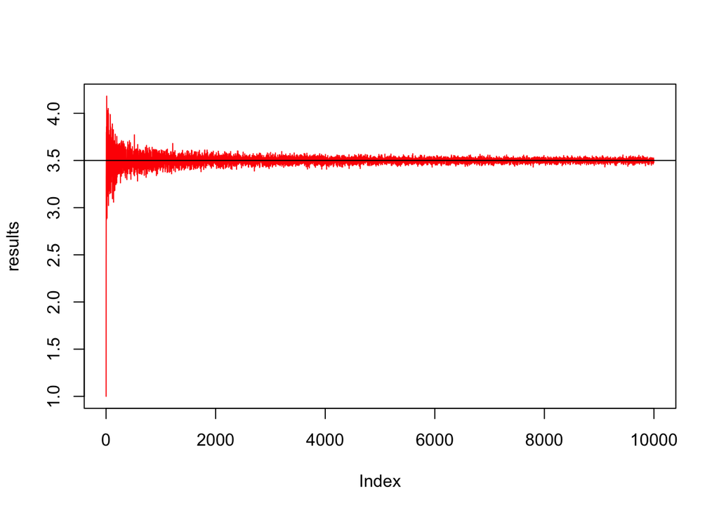

```r
sample_size_n_grid <- 1:10000
results <- rep(NA, 10000)
set.seed(1)
for (sample_size_n in 1:10000){
  # current sample size: sample_size_n
  results[sample_size_n] <- mean(sample(1:6, size = sample_size_n, replace = TRUE))
}
plot(results, type = "l", col = "red")
abline(h = 3.5)
```

LNN vs CLT:

- The CLT states that the normalized average of i.i.d. random variables converges in distribution to a standard normal random variable. That is, let $X_{1}, X_{2}, \ldots, X_{n}$ be i.i.d. random variables with expected value $E X_{i}=\mu<\infty$ and variance $\operatorname{Var}\left(X_{i}\right)=\sigma^{2}<\infty$. Then, the random variable
  $$Z_{n}=\frac{\bar{X}-\mu}{\sigma / \sqrt{n}}$$
  converges in distribution to the standard normal random variable as $n$ goes to infinity, that is
  $$\lim _{n \rightarrow \infty} P\left(Z_{n} \leq x\right)=\Phi(x), \quad \text { for all } x \in \mathbb{R}$$
  where $\Phi(x)$ is the standard normal CDF.
- Central Limit Theorem (CLT) “refines” LNN. It establishes the normal distribution as the distribution to which the mean (average) of almost any set of independent and randomly generated variables converges. Since it gives the variance of this normal distribution, it tells us the *rate* at which sample mean converges to population mean parameter as sample size $n$ increases.

#### Examples from the lecture

##### (1) Example of a sequence of unbiased estimators that does not converge in probability?

Consider $X_1, X_2, \ldots$ - random variable $\sim Bernoulli(p)$. Consider sequence of estimators of true fixed unknown parameter $p$ defined as

$$\theta_n = X_1$$

(i.e., regardless of sequence number $n$, the element of a sequence – the $n$-th estimator – is defined as this one random variable $X_1$).

- Is $\theta_n$ unbiased? Show that for any $n$ we have $E(\theta_n) = p$.
- Does $\theta_n$ converge in probability to $p$? Show we do not have $P\left(\mid \theta_{n}-p \mid<\epsilon\right) \rightarrow 1$.

Let’s consider some fixed $\epsilon > 0$.

$$\begin{aligned}
P\left( |\theta_{n}-p | <\epsilon\right)
& = P \left( |X_1 -p | <\epsilon\right) \\
& = P \left(- \epsilon < X_1 -p <\epsilon\right) \\
& = P \left(- \epsilon + p < X_1 <\epsilon + p\right) \\
\end{aligned}$$

is fixed for any fixed $\epsilon > 0$ (**does not** go to 1 as $n \to \infty$).

##### (2) Example of sequence of estimators that are not unbiased but converges in probability to parameter of interest?

Consider $X_1, X_2, \ldots$ - random variables $\sim Bernoulli(p)$. Consider sequence of estimators of true fixed unknown parameter $p$ defined as

$$\theta_n = \bar{X}_n + \frac{1}{n}$$

- Is $\theta_n$ biased? Show that for any $n$ we have $E(\theta_n) \neq p$.
- Does $\theta_n$ converge in probability to $p$? Show we have $P\left(\mid \theta_{n}-p \mid<\epsilon\right) \rightarrow 1$.

$$\begin{aligned}
P\left( |\theta_{n}-p | <\epsilon\right)
& = P \left( |\bar{X}_n + \frac{1}{n}-p | <\epsilon\right) \\
& = \ldots
\end{aligned}$$

#### Other examples

##### (3) Example of a sequence of biased estimators that converge in distribution to some random variable $X$?

- State what is the quantity that estimator is estimating
- Propose estimator sequence
- Show biasedness
- Show it converges in distribution to (any) random variable $X$

Hint: consider $X_{1}, X_{2} \ldots \text { iid }, X_{i} \sim N\left(\mu, \sigma^{2}\right)$ for each $i \in \mathbb{N}$. Consider a corresponding sequence $\left\{\hat{\mu}_{n}\right\}$ of estimators of $\mu$ parameter, where $n$-th element of the sequence is given by
$$\hat{\mu}_{n}=X_{1}+1.$$
(Note we have index ’‘$_1$’’ in $X_1$ regardless of index ’‘$_n$’’ in $\hat{\mu}_n$. )

- Show $\hat{\mu}_n$ is a biased estimator of $\mu$ parameter for any $n$.
- Show sequence $\left\{\hat{\mu}_{n}\right\}$ converges in distribution. Hint: what is the distribution of $X_{1}+1$? Note it is so for each $n$ (hence in particular: as we take limit $n \to \infty$).

Bonus question: can you show sequence $\left\{\hat{\mu}_{n}\right\}$ does not converge in probability to true unknown fixed parameter $\mu$?

#### 2010 Final Problem 1

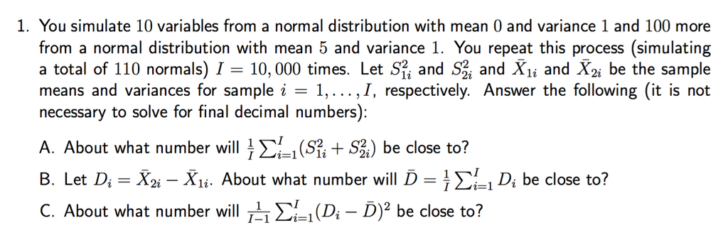

##### (A) About what number will $\frac{1}{I}\sum_{i=1}^I (S_{1i}^2+S_{2i}^2)$ be close to?

- Use the Law of Large Numbers. View $\left(S_{1i}^2+S_{2i}^2 \right)$, $i=1,\ldots,I$ as $I$ individual observations.
- As $I$ goes to infinity, $\frac{1}{I}\sum_{i=1}^I (S_{1i}^2+S_{2i}^2)$ converges in probability to $E[S_{11}^2+S_{21}^2]$.
- $S_{11}^2$ and $S_{21}^2$ are unbiased estimators of the variance of the two sample: $E[S_{11}^2]=E[S_{21}^2]=1$ and $E[S_{11}^2+S_{21}^2]=2$. Hence $\frac{1}{I}\sum_{i=1}^I (S_{1i}^2+S_{2i}^2)$ will be close to 2.

##### (B) Let $D_i=\bar{X}_{2i}-\bar{X}_{1i}$. About what number will $\bar{D}=\frac{1}{I}\sum_{i=1}^I D_i$ will be close to?

Lecture material revisited:

- Sample means of normal random variables are normally distributed.
- The difference of two normal random variables are normally distributed.

$$\bar{X}_{1}\sim N(0,1/10), \bar{X}_{2}\sim N(5,1/100).$$
.

$$E[D_i] = E[\bar{X}_2]-E[\bar{X}_1]=5.$$

Since $\bar{X}_1$ and $\bar{X}_2$ are independent, $var(D_i)=var(\bar{X}_1)+var(\bar{X}_2)=11/100$.

Therefore $D_i\sim N(5,11/100)$.

Again by the LLN, $\bar{D}$ converges to 5 in probability.

##### (C) About what number will $\frac{1}{I-1}\sum_{i=1}^I(D_i-\bar{D})$ be close to?

$$\frac{1}{I-1}\sum_{i=1}^I(D_i-\bar{D})\overset{p}{\to} var(D_1)=11/100.$$
See lecture 8 page 18 for details.

### 2. Likelihood

- The likelihood of the data is the joint density evaluated as a with the data fixed.
  - Given data $\boldsymbol{x}$ and PMF or PDF $f(\boldsymbol{x},\theta)$, the likelihood is $L(\theta \mid \boldsymbol{x})=f(\boldsymbol{x},\theta)$.
- Ratios of likelihood values measure the relative evidence of one value of the unknown parameter to another.

#### 2010 Final Problem 2

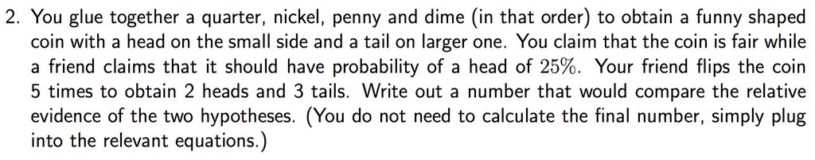

#### Compute the likelihood ratio!

Denote by $p$ the probability of heads.

Likelihood $L(p\mid \boldsymbol{x})=\frac{5!}{2!3!}p^2 (1-p)^3$.

Likelihood ratio $\frac{L(0.5\mid \boldsymbol{x})}{L(0.25\mid \boldsymbol{x})} = \frac{\frac{5!}{2!3!}0.5^2 (1-0.5)^3}{\frac{5!}{2!3!}0.25^2 (1-0.25)^3}\approx 1.19$. There is more evidence supporting that the coin is fair than that the probability of heads is 0.25.

### 3. Maximum likelihood

Three steps to compute the maximum likelhood estimate:

1. Write down the log-likelihood $l(\theta\mid \boldsymbol{x}) = logL(\theta \mid \boldsymbol{x})=\sum_{i=1}^n logf(x_i\mid\theta)$.
2. Solve the score equation $\frac{d}{d\theta}l(\theta\mid\boldsymbol{x})=0$.
3. Check $\frac{d^2}{d\theta^2}l(\theta\mid\boldsymbol{x})<0$.

#### 2010 Final Problem 3

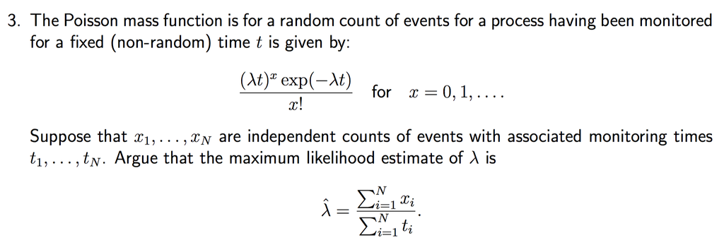

1. Since the observations are independent, the likelihood is the product of individual PMFs:
   $$L(\lambda\mid\boldsymbol{x}) = \prod\limits_{i=1}^N \frac{(\lambda t_i)^{x_i}\exp(-\lambda t_i)}{x_i !} = \lambda^{\sum_{i=1}^N x_i}\exp\Big(-\lambda\sum_{i=1}^N t_i\Big)\prod\limits_{i=1}^N \frac{t_i^{x_i}}{x_i !}$$

The log-likelihood is
$$l(\lambda\mid\boldsymbol{x})=(\sum_{i=1}^N x_i)log(\lambda)-\lambda\sum_{i=1}^N t_i+C.$$
$C$ is a constant.

2. The score equation is

$$\frac{d}{d\lambda}l(\theta\mid\boldsymbol{x})=\frac{\sum_{i=1}^N x_i}{\lambda}-\sum_{i=1}^N t_i=0.$$
Soving the equation gives
$$\hat{\lambda}=\frac{\sum_{i=1}^N x_i}{\sum_{i=1}^N t_i}.$$

3. Compute the second derivative
   $$\frac{d^2}{d\lambda^2}l(\lambda\mid\boldsymbol{x})=-\frac{\sum_{i=1}^N x_i}{\lambda^2}<0.$$
   Therefore $\hat{\lambda}=\frac{\sum_{i=1}^N x_i}{\sum_{i=1}^N t_i}$ is the MLE of $\lambda$.

### 4. Confidence intervals

#### 2010 Final Problem 6

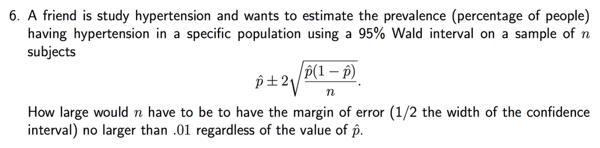

1. (Derivation) The sample prevalence $\hat{p}$ is a consistent (and unbiased) estimate of the population prevalence $p$.

$$E[\hat{p}]=p \\
var(\hat{p})=p(1-p)/n$$
.

Using the Central Limit Theorem, when the sample size is large, $\hat{p}$ is approximately distributed as $N\Big(p,\frac{p(1-p)}{n}\Big)$.

Hence
$$P\Big(|\hat{p}-p|\leq 2\sqrt{p(1-p)/n}\Big)=0.95=P\Big(\hat{p}-2\sqrt{p(1-p)/n}\leq p\leq \hat{p}+2\sqrt{p(1-p)/n}\Big).$$
Hence the confidence interval is $\hat{p}\pm 2\sqrt{p(1-p)/n}$.

Replace $p$ by $\hat{p}$ gives CI $\hat{p}\pm 2\sqrt{\hat{p}(1-\hat{p})/n}$. (Why is this substitution correct? Hint: Slutsky’s theorem.)

2. (Size of CI) Half the length of the confidence interval is
   $$2\sqrt{\hat{p}(1-\hat{p})/n}\leq2\sqrt{1/(4n)}=1/\sqrt{n}\leq 0.01$$
   .
   $$n\geq 10,000.$$

Review:

- Confidence intervals are random! The parameter is fixed.
- For example, if we obtain a 95% percent confidence interval for [0.45,0.57]
  - It is **wrong** to interpret it as “the probability for $p$ to be in [0.45,0.57] is 95%”.
  - The correct interpretation is: if we repeat the same procedure many times and get a confidence interval each time, 95% of those intervals will include $p$. One of the realizations of the interval is [0.45,0.57].
- The length of the confidence interval is proportional to $1/\sqrt{n}$.